# Rumi Allbert Homework 1

## 3.3.1 Exercises

### Q1: What’s gone wrong with this code? Why are the points not blue?

### Answer:

The reason why the points are not blue is because the condition: “colour =”blue"" is within the aes(), meaning it is within the aesthetics of the mapping. In order for the points to be blue we would need to move the condition outside the mapping, in this way:

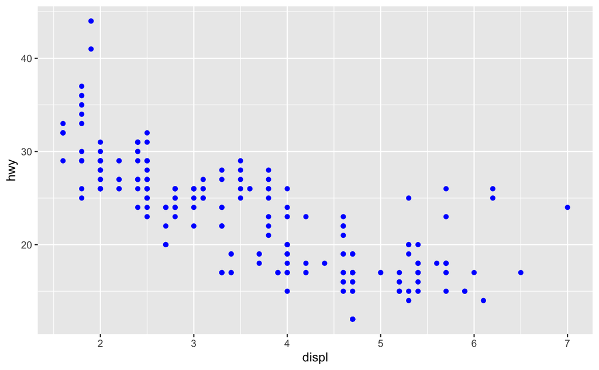

```r
ggplot(data = mpg) +
  geom_point(mapping = aes(x = displ, y = hwy), color = "blue")
```

### Q5: What does the stroke aesthetic do? What shapes does it work with? (Hint: use ?geom_point)

### Answer:

The stroke aesthetic changes the size of the shapes border, we can take the same example as before and add a stroke aesthetic.

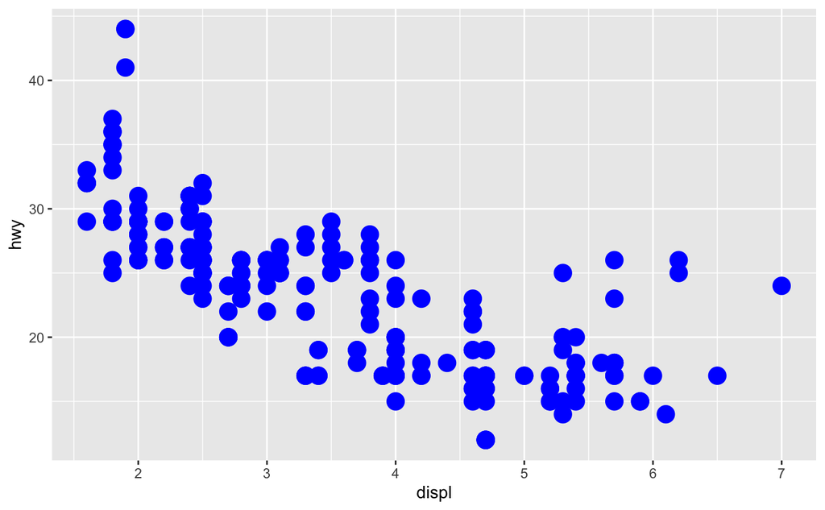

```r
ggplot(data = mpg) +
  geom_point(mapping = aes(x = displ, y = hwy, stroke = 3), color = "blue")
```

## 3.5.1 Exercises

### Q2: What do the empty cells in plot with facet_grid(drv ~ cyl) mean? How do they relate to this plot?

### Answer:

The empty cells in the graph represent the areas where drv and cyl have no observations.

### Q3: What plots does the following code make? What does . do?

### Answer:

The following code creates the following graphs, while the . specifies dimension when creating the facet.

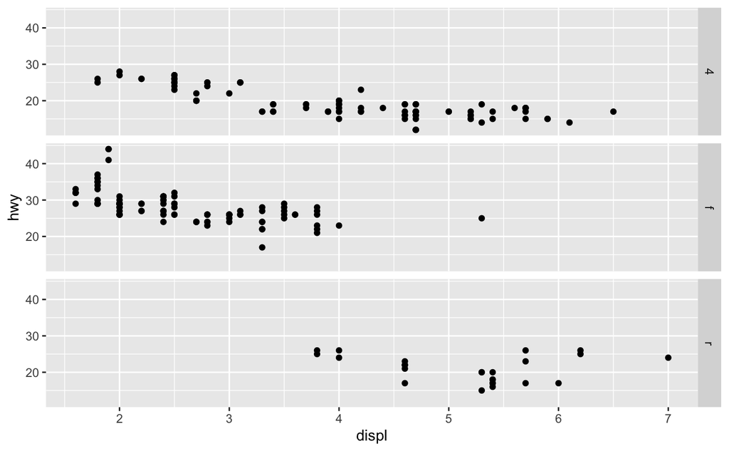

```r
ggplot(data = mpg) +
  geom_point(mapping = aes(x = displ, y = hwy)) +
  facet_grid(drv ~ .)
```

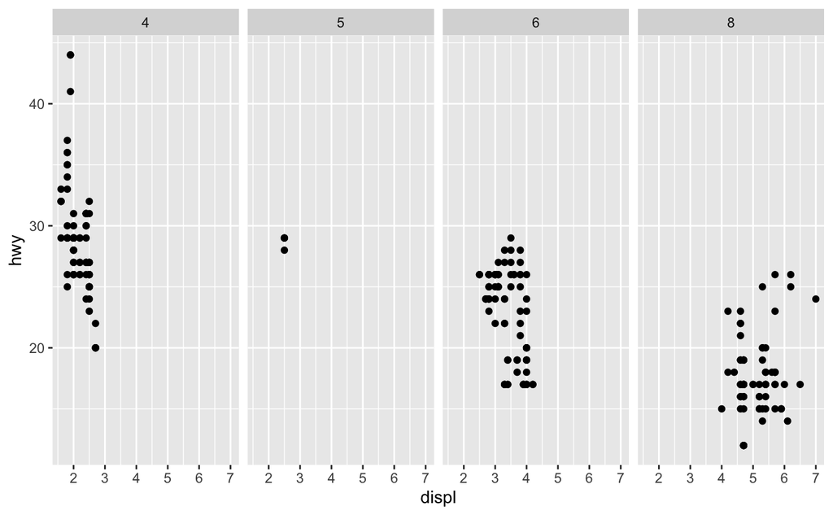

```r
ggplot(data = mpg) +
  geom_point(mapping = aes(x = displ, y = hwy)) +
  facet_grid(. ~ cyl)
```

### Q5: Read ?facet_wrap. What does nrow do? What does ncol do? What other options control the layout of the individual panels? Why doesn’t facet_grid() have nrow and ncol arguments?

### Answer:

nrow and ncol give you the number of rows and columns, respectively. facet_grid() doesn’t require nrow and ncol since these are specified when utilizing facet_grid().

## 3.6.1 Exercises

### Q6: Recreate the R code necessary to generate the following graphs.

### Answer:

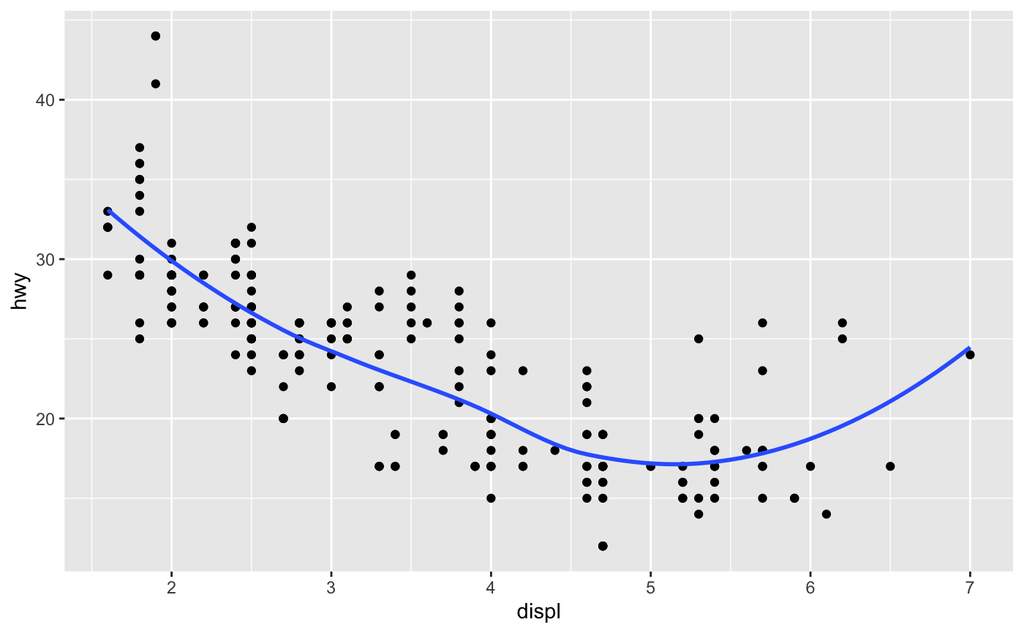

```r
ggplot(mpg, aes(x = displ, y = hwy)) + geom_point() + geom_smooth(se = FALSE)
```

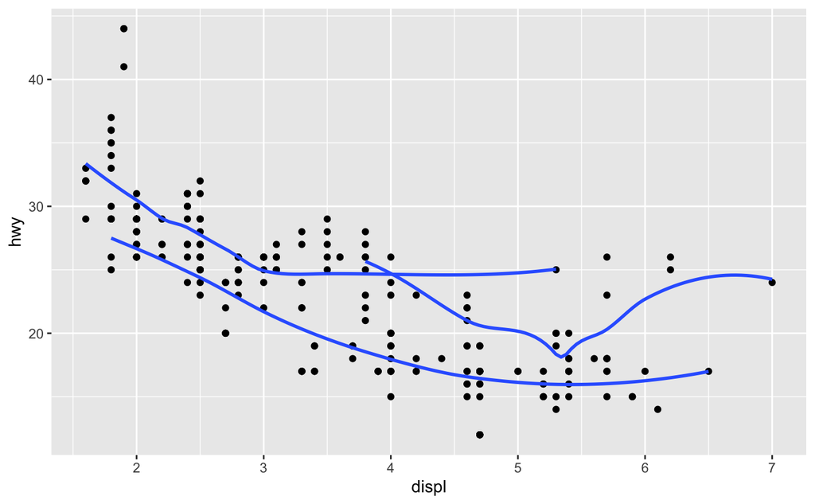

```r
ggplot(mpg, aes(x = displ, y = hwy)) + geom_point() + geom_smooth(mapping = aes(group = drv), se = FALSE)
```

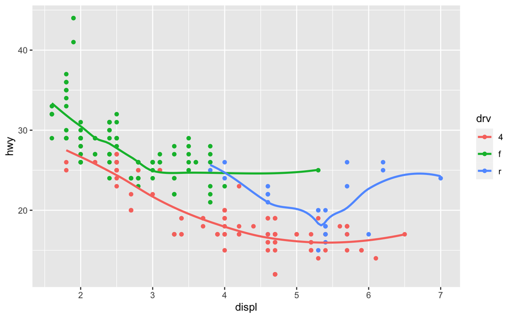

```r
ggplot(mpg, aes(x = displ, y = hwy, colour = drv)) + geom_point() + geom_smooth(se = FALSE)
```

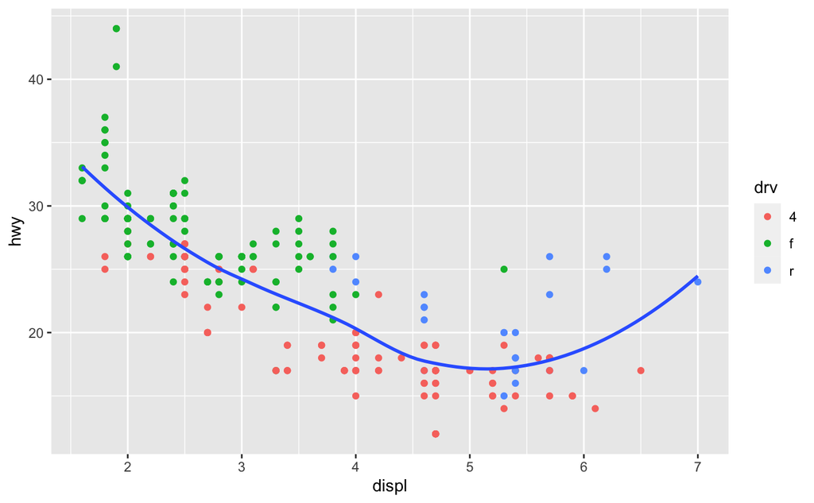

```r
ggplot(mpg, aes(x = displ, y = hwy)) + geom_point(aes(colour = drv)) + geom_smooth(se = FALSE)
```

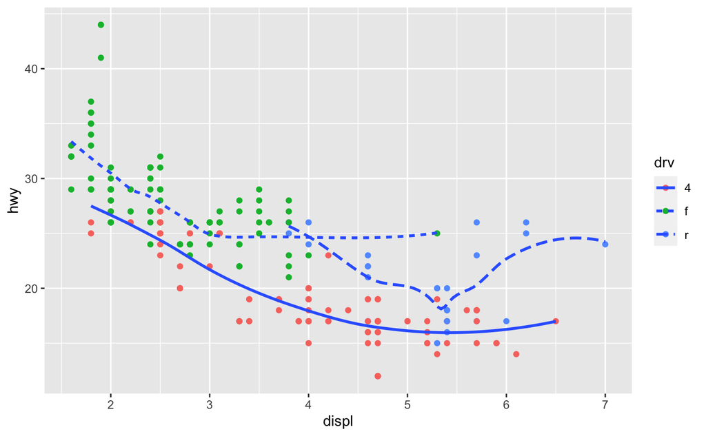

```r
ggplot(mpg, aes(x = displ, y = hwy)) + geom_point(aes(colour = drv)) + geom_smooth(aes(linetype = drv), se = FALSE)
```

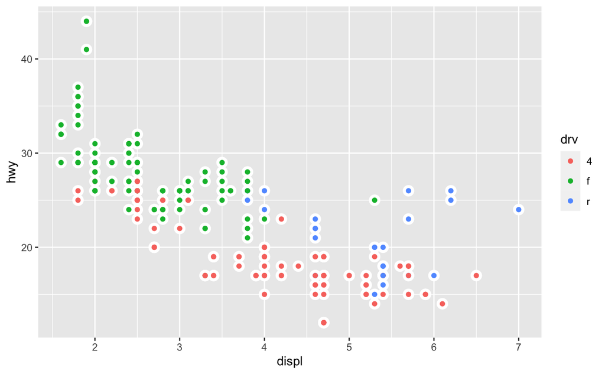

```r
ggplot(mpg, aes(x = displ, y = hwy)) + geom_point(size = 4, color = "white") + geom_point(aes(colour = drv))
```